# ANCOVA in Vocabulario (Vocabulario)

Geiser C. Challco geiser@alumni.usp.br

- Descriptive Statistics of Initial Data
- ANCOVA and Pairwise for one factor: **grupo**
  - Without remove non-normal data
  - Computing ANCOVA and PairWise After removing non-normal data (OK)
    - Plots for ancova
    - Checking linearity assumption
    - Checking normality and homogeneity
- ANCOVA and Pairwise for two factors **grupo:Sexo**
  - Without remove non-normal data
  - Computing ANCOVA and PairWise After removing non-normal data (OK)
    - Plots for ancova
    - Checking linearity assumption
    - Checking normality and homogeneity
- ANCOVA and Pairwise for two factors **grupo:Zona**
  - Without remove non-normal data
  - Computing ANCOVA and PairWise After removing non-normal data (OK)
    - Plots for ancova
    - Checking linearity assumption
    - Checking normality and homogeneity
- ANCOVA and Pairwise for two factors **grupo:Cor.Raca**
  - Without remove non-normal data
  - Computing ANCOVA and PairWise After removing non-normal data (OK)
    - Plots for ancova
    - Checking linearity assumption
    - Checking normality and homogeneity
- ANCOVA and Pairwise for two factors **grupo:vocab.quintile**
  - Without remove non-normal data
  - Computing ANCOVA and PairWise After removing non-normal data (OK)
    - Plots for ancova
    - Checking linearity assumption
    - Checking normality and homogeneity
- Summary of Results
  - Descriptive Statistics
  - ANCOVA Table Comparison
  - PairWise Table Comparison
  - EMMS Table Comparison

**NOTE**:

- Teste ANCOVA para determinar se houve diferenças significativas no Vocabulario (medido usando pre- e pos-testes).
- ANCOVA test to determine whether there were significant differences in Vocabulario (measured using pre- and post-tests).

# Descriptive Statistics of Initial Data

```r
df <- get.descriptives(dat, c(dv.pre, dv.pos), c("grupo"),
                       include.global = T, symmetry.test = T, normality.test = F)
df <- plyr::rbind.fill(
  df, do.call(plyr::rbind.fill, lapply(lfatores2, FUN = function(f) {
    if (nrow(dat) > 0 && sum(!is.na(unique(dat[[f]]))) > 1)
      get.descriptives(dat, c(dv.pre,dv.pos), c("grupo", f),
                       symmetry.test = T, normality.test = F)
    }))
)
(df <- df[,c(fatores1[fatores1 %in% colnames(df)],"variable",
             colnames(df)[!colnames(df) %in% c(fatores1,"variable")])])
```

```
##           grupo Sexo   Zona Cor.Raca vocab.quintile  variable   n   mean median min max     sd    se     ci
## 1      Controle <NA>   <NA>     <NA>           <NA> vocab.pre 146 21.349   20.5   4  41  8.648 0.716  1.415
## 2  Experimental <NA>   <NA>     <NA>           <NA> vocab.pre 165 23.012   23.0   6  43  8.546 0.665  1.314
## 3          <NA> <NA>   <NA>     <NA>           <NA> vocab.pre 311 22.232   22.0   4  43  8.621 0.489  0.962
## 4      Controle <NA>   <NA>     <NA>           <NA> vocab.pos 146 22.411   21.0   2  40  9.023 0.747  1.476
## 5  Experimental <NA>   <NA>     <NA>           <NA> vocab.pos 165 24.836   25.0   2  44  9.175 0.714  1.410
## 6          <NA> <NA>   <NA>     <NA>           <NA> vocab.pos 311 23.698   23.0   2  44  9.170 0.520  1.023
## 7      Controle    F   <NA>     <NA>           <NA> vocab.pre  65 22.846   23.0   7  39  8.275 1.026  2.050
## 8      Controle    M   <NA>     <NA>           <NA> vocab.pre  81 20.148   18.0   4  41  8.804 0.978  1.947
## 9  Experimental    F   <NA>     <NA>           <NA> vocab.pre  88 24.261   25.5   6  43  8.732 0.931  1.850
## 10 Experimental    M   <NA>     <NA>           <NA> vocab.pre  77 21.584   20.0   6  38  8.152 0.929  1.850
## 11     Controle    F   <NA>     <NA>           <NA> vocab.pos  65 24.723   25.0   4  39  8.438 1.047  2.091
## 12     Controle    M   <NA>     <NA>           <NA> vocab.pos  81 20.556   19.0   2  40  9.098 1.011  2.012
## 13 Experimental    F   <NA>     <NA>           <NA> vocab.pos  88 26.432   27.0   2  44  9.156 0.976  1.940
## 14 Experimental    M   <NA>     <NA>           <NA> vocab.pos  77 23.013   21.0   6  42  8.908 1.015  2.022
```

[output cut: 98 more lines]

| grupo | Sexo | Zona | Cor.Raca | vocab.quintile | variable | n | mean | median | min | max | sd | se | ci | iqr | symmetry | skewness | kurtosis |
| --- | --- | --- | --- | --- | --- | --- | --- | --- | --- | --- | --- | --- | --- | --- | --- | --- | --- |
| Controle |  |  |  |  | vocab.pre | 146 | 21.349 | 20.5 | 4 | 41 | 8.648 | 0.716 | 1.415 | 12.75 | YES | 0.277 | -0.859 |
| Experimental |  |  |  |  | vocab.pre | 165 | 23.012 | 23.0 | 6 | 43 | 8.546 | 0.665 | 1.314 | 14.00 | YES | 0.049 | -1.010 |
|  |  |  |  |  | vocab.pre | 311 | 22.232 | 22.0 | 4 | 43 | 8.621 | 0.489 | 0.962 | 14.00 | YES | 0.153 | -0.952 |
| Controle |  |  |  |  | vocab.pos | 146 | 22.411 | 21.0 | 2 | 40 | 9.023 | 0.747 | 1.476 | 14.50 | YES | 0.096 | -0.871 |
| Experimental |  |  |  |  | vocab.pos | 165 | 24.836 | 25.0 | 2 | 44 | 9.175 | 0.714 | 1.410 | 14.00 | YES | 0.014 | -0.841 |
|  |  |  |  |  | vocab.pos | 311 | 23.698 | 23.0 | 2 | 44 | 9.170 | 0.520 | 1.023 | 15.00 | YES | 0.057 | -0.833 |
| Controle | F |  |  |  | vocab.pre | 65 | 22.846 | 23.0 | 7 | 39 | 8.275 | 1.026 | 2.050 | 14.00 | YES | 0.149 | -0.968 |
| Controle | M |  |  |  | vocab.pre | 81 | 20.148 | 18.0 | 4 | 41 | 8.804 | 0.978 | 1.947 | 13.00 | YES | 0.421 | -0.749 |
| Experimental | F |  |  |  | vocab.pre | 88 | 24.261 | 25.5 | 6 | 43 | 8.732 | 0.931 | 1.850 | 12.25 | YES | -0.221 | -0.849 |
| Experimental | M |  |  |  | vocab.pre | 77 | 21.584 | 20.0 | 6 | 38 | 8.152 | 0.929 | 1.850 | 12.00 | YES | 0.354 | -1.013 |
| Controle | F |  |  |  | vocab.pos | 65 | 24.723 | 25.0 | 4 | 39 | 8.438 | 1.047 | 2.091 | 14.00 | YES | -0.139 | -0.860 |
| Controle | M |  |  |  | vocab.pos | 81 | 20.556 | 19.0 | 2 | 40 | 9.098 | 1.011 | 2.012 | 14.00 | YES | 0.339 | -0.707 |
| Experimental | F |  |  |  | vocab.pos | 88 | 26.432 | 27.0 | 2 | 44 | 9.156 | 0.976 | 1.940 | 14.00 | YES | -0.231 | -0.733 |
| Experimental | M |  |  |  | vocab.pos | 77 | 23.013 | 21.0 | 6 | 42 | 8.908 | 1.015 | 2.022 | 14.00 | YES | 0.286 | -0.728 |
| Controle |  | Rural |  |  | vocab.pre | 97 | 22.134 | 23.0 | 4 | 39 | 8.309 | 0.844 | 1.675 | 13.00 | YES | 0.026 | -0.859 |
| Controle |  | Urbana |  |  | vocab.pre | 28 | 23.214 | 21.5 | 10 | 41 | 10.082 | 1.905 | 3.910 | 18.25 | YES | 0.259 | -1.434 |
| Controle |  |  |  |  | vocab.pre | 21 | 15.238 | 14.0 | 6 | 25 | 5.157 | 1.125 | 2.347 | 7.00 | YES | 0.232 | -0.861 |
| Experimental |  | Rural |  |  | vocab.pre | 85 | 21.941 | 22.0 | 6 | 43 | 8.324 | 0.903 | 1.796 | 14.00 | YES | 0.110 | -0.903 |
| Experimental |  | Urbana |  |  | vocab.pre | 38 | 24.316 | 25.5 | 9 | 38 | 8.737 | 1.417 | 2.872 | 13.50 | YES | -0.071 | -1.286 |
| Experimental |  |  |  |  | vocab.pre | 42 | 24.000 | 24.0 | 9 | 39 | 8.737 | 1.348 | 2.723 | 13.50 | YES | -0.008 | -1.111 |
| Controle |  | Rural |  |  | vocab.pos | 97 | 22.928 | 24.0 | 2 | 40 | 9.275 | 0.942 | 1.869 | 15.00 | YES | -0.051 | -0.944 |
| Controle |  | Urbana |  |  | vocab.pos | 28 | 24.821 | 23.0 | 9 | 38 | 8.710 | 1.646 | 3.377 | 14.00 | YES | 0.070 | -1.245 |
| Controle |  |  |  |  | vocab.pos | 21 | 16.810 | 17.0 | 5 | 28 | 5.706 | 1.245 | 2.597 | 5.00 | YES | -0.113 | -0.379 |
| Experimental |  | Rural |  |  | vocab.pos | 85 | 23.741 | 23.0 | 2 | 42 | 8.580 | 0.931 | 1.851 | 12.00 | YES | 0.030 | -0.489 |
| Experimental |  | Urbana |  |  | vocab.pos | 38 | 26.158 | 25.0 | 9 | 41 | 9.579 | 1.554 | 3.149 | 16.50 | YES | -0.013 | -1.332 |
| Experimental |  |  |  |  | vocab.pos | 42 | 25.857 | 27.0 | 8 | 44 | 9.894 | 1.527 | 3.083 | 16.50 | YES | -0.119 | -1.118 |
| Controle |  |  | Branca |  | vocab.pre | 22 | 23.000 | 24.5 | 8 | 36 | 7.400 | 1.578 | 3.281 | 5.75 | YES | -0.467 | -0.544 |
| Controle |  |  | Indígena |  | vocab.pre | 2 | 24.000 | 24.0 | 23 | 25 | 1.414 | 1.000 | 12.706 | 1.00 | few data | 0.000 | 0.000 |
| Controle |  |  | Parda |  | vocab.pre | 42 | 21.405 | 19.5 | 7 | 39 | 9.240 | 1.426 | 2.879 | 16.00 | YES | 0.462 | -1.089 |
| Controle |  |  | Preta |  | vocab.pre | 1 | 19.000 | 19.0 | 19 | 19 |  |  |  | 0.00 | few data | 0.000 | 0.000 |
| Controle |  |  |  |  | vocab.pre | 79 | 20.823 | 19.0 | 4 | 41 | 8.837 | 0.994 | 1.979 | 13.00 | YES | 0.335 | -0.852 |
| Experimental |  |  | Branca |  | vocab.pre | 18 | 25.500 | 25.5 | 12 | 38 | 8.053 | 1.898 | 4.005 | 11.25 | YES | -0.051 | -1.230 |
| Experimental |  |  | Indígena |  | vocab.pre | 13 | 21.000 | 22.0 | 12 | 34 | 7.506 | 2.082 | 4.536 | 13.00 | YES | 0.283 | -1.548 |
| Experimental |  |  | Parda |  | vocab.pre | 44 | 21.795 | 21.5 | 6 | 35 | 8.154 | 1.229 | 2.479 | 13.25 | YES | -0.116 | -1.192 |
| Experimental |  |  | Preta |  | vocab.pre | 1 | 10.000 | 10.0 | 10 | 10 |  |  |  | 0.00 | few data | 0.000 | 0.000 |
| Experimental |  |  |  |  | vocab.pre | 89 | 23.551 | 23.0 | 9 | 43 | 8.865 | 0.940 | 1.867 | 14.00 | YES | 0.063 | -1.041 |
| Controle |  |  | Branca |  | vocab.pos | 22 | 23.727 | 24.5 | 10 | 37 | 8.282 | 1.766 | 3.672 | 12.00 | YES | -0.115 | -1.216 |
| Controle |  |  | Indígena |  | vocab.pos | 2 | 30.000 | 30.0 | 29 | 31 | 1.414 | 1.000 | 12.706 | 1.00 | few data | 0.000 | 0.000 |
| Controle |  |  | Parda |  | vocab.pos | 42 | 22.167 | 21.0 | 4 | 39 | 9.845 | 1.519 | 3.068 | 18.00 | YES | 0.100 | -1.262 |
| Controle |  |  | Preta |  | vocab.pos | 1 | 24.000 | 24.0 | 24 | 24 |  |  |  | 0.00 | few data | 0.000 | 0.000 |
| Controle |  |  |  |  | vocab.pos | 79 | 21.962 | 21.0 | 2 | 40 | 8.926 | 1.004 | 1.999 | 11.50 | YES | 0.219 | -0.624 |
| Experimental |  |  | Branca |  | vocab.pos | 18 | 24.333 | 21.0 | 6 | 41 | 11.314 | 2.667 | 5.626 | 18.50 | YES | 0.109 | -1.553 |
| Experimental |  |  | Indígena |  | vocab.pos | 13 | 24.308 | 23.0 | 13 | 39 | 8.625 | 2.392 | 5.212 | 15.00 | YES | 0.294 | -1.411 |
| Experimental |  |  | Parda |  | vocab.pos | 44 | 24.477 | 25.0 | 9 | 42 | 8.188 | 1.234 | 2.489 | 12.25 | YES | -0.097 | -0.980 |
| Experimental |  |  | Preta |  | vocab.pos | 1 | 13.000 | 13.0 | 13 | 13 |  |  |  | 0.00 | few data | 0.000 | 0.000 |
| Experimental |  |  |  |  | vocab.pos | 89 | 25.326 | 25.0 | 2 | 44 | 9.340 | 0.990 | 1.968 | 14.00 | YES | -0.041 | -0.698 |
| Controle |  |  |  | 1st quintile | vocab.pre | 50 | 12.140 | 12.5 | 4 | 16 | 2.942 | 0.416 | 0.836 | 3.75 | NO | -0.615 | -0.231 |
| Controle |  |  |  | 2nd quintile | vocab.pre | 31 | 19.226 | 19.0 | 17 | 22 | 1.802 | 0.324 | 0.661 | 3.00 | YES | 0.169 | -1.368 |
| Controle |  |  |  | 3rd quintile | vocab.pre | 33 | 25.061 | 25.0 | 23 | 29 | 1.767 | 0.308 | 0.626 | 2.00 | NO | 0.637 | -0.469 |
| Controle |  |  |  | 4th quintile | vocab.pre | 19 | 31.895 | 32.0 | 30 | 34 | 1.663 | 0.382 | 0.802 | 3.50 | YES | 0.020 | -1.683 |
| Controle |  |  |  | 5th quintile | vocab.pre | 13 | 37.000 | 37.0 | 35 | 41 | 1.871 | 0.519 | 1.131 | 3.00 | NO | 0.564 | -0.777 |
| Experimental |  |  |  | 1st quintile | vocab.pre | 48 | 12.667 | 13.0 | 6 | 16 | 2.747 | 0.396 | 0.798 | 5.25 | YES | -0.418 | -0.620 |
| Experimental |  |  |  | 2nd quintile | vocab.pre | 32 | 19.781 | 20.0 | 17 | 22 | 1.736 | 0.307 | 0.626 | 3.00 | YES | -0.175 | -1.369 |
| Experimental |  |  |  | 3rd quintile | vocab.pre | 40 | 26.050 | 26.0 | 23 | 29 | 2.075 | 0.328 | 0.664 | 4.00 | YES | -0.098 | -1.343 |
| Experimental |  |  |  | 4th quintile | vocab.pre | 28 | 31.571 | 31.5 | 30 | 34 | 1.317 | 0.249 | 0.511 | 3.00 | YES | 0.226 | -1.290 |
| Experimental |  |  |  | 5th quintile | vocab.pre | 17 | 37.059 | 37.0 | 35 | 43 | 2.076 | 0.503 | 1.067 | 3.00 | NO | 1.189 | 1.338 |
| Controle |  |  |  | 1st quintile | vocab.pos | 50 | 14.200 | 15.0 | 2 | 26 | 4.949 | 0.700 | 1.406 | 6.00 | YES | -0.279 | -0.112 |
| Controle |  |  |  | 2nd quintile | vocab.pos | 31 | 20.484 | 21.0 | 10 | 29 | 5.072 | 0.911 | 1.860 | 7.50 | YES | -0.219 | -0.948 |
| Controle |  |  |  | 3rd quintile | vocab.pos | 33 | 25.091 | 25.0 | 9 | 38 | 5.897 | 1.027 | 2.091 | 7.00 | NO | -0.561 | 0.510 |
| Controle |  |  |  | 4th quintile | vocab.pos | 19 | 32.579 | 33.0 | 24 | 39 | 3.687 | 0.846 | 1.777 | 3.00 | YES | -0.369 | -0.016 |
| Controle |  |  |  | 5th quintile | vocab.pos | 13 | 36.923 | 37.0 | 33 | 40 | 2.060 | 0.571 | 1.245 | 2.00 | YES | -0.381 | -1.053 |
| Experimental |  |  |  | 1st quintile | vocab.pos | 48 | 17.958 | 16.5 | 2 | 42 | 7.423 | 1.071 | 2.155 | 9.25 | NO | 0.807 | 1.011 |
| Experimental |  |  |  | 2nd quintile | vocab.pos | 32 | 20.594 | 21.0 | 6 | 35 | 5.780 | 1.022 | 2.084 | 6.25 | YES | -0.336 | 0.592 |
| Experimental |  |  |  | 3rd quintile | vocab.pos | 40 | 27.400 | 30.0 | 13 | 44 | 7.815 | 1.236 | 2.499 | 12.25 | YES | -0.308 | -0.885 |
| Experimental |  |  |  | 4th quintile | vocab.pos | 28 | 30.393 | 30.5 | 14 | 38 | 5.080 | 0.960 | 1.970 | 4.50 | NO | -1.183 | 1.957 |
| Experimental |  |  |  | 5th quintile | vocab.pos | 17 | 37.059 | 40.0 | 21 | 43 | 6.057 | 1.469 | 3.114 | 5.00 | NO | -1.338 | 0.764 |

# ANCOVA and Pairwise for one factor: **grupo**

## Without remove non-normal data

```r
pdat = remove_group_data(dat[!is.na(dat[["grupo"]]),], "vocab.pos", "grupo")

pdat.long <- rbind(pdat[,c("id","grupo")], pdat[,c("id","grupo")])
pdat.long[["time"]] <- c(rep("pre", nrow(pdat)), rep("pos", nrow(pdat)))
pdat.long[["time"]] <- factor(pdat.long[["time"]], c("pre","pos"))
pdat.long[["vocab"]] <- c(pdat[["vocab.pre"]], pdat[["vocab.pos"]])

aov = anova_test(pdat, vocab.pos ~ vocab.pre + grupo)
laov[["grupo"]] <- get_anova_table(aov)
```

```r
pwc <- emmeans_test(pdat, vocab.pos ~ grupo, covariate = vocab.pre,
                    p.adjust.method = "bonferroni")
```

```r
pwc.long <- emmeans_test(dplyr::group_by_at(pdat.long, "grupo"),
                          vocab ~ time,
                          p.adjust.method = "bonferroni")
lpwc[["grupo"]] <- plyr::rbind.fill(pwc, pwc.long)
```

```r
ds <- get.descriptives(pdat, "vocab.pos", "grupo", covar = "vocab.pre")
ds <- merge(ds[ds$variable != "vocab.pre",],
            ds[ds$variable == "vocab.pre", !colnames(ds) %in% c("variable")],
            by = "grupo", all.x = T, suffixes = c("", ".vocab.pre"))
ds <- merge(get_emmeans(pwc), ds, by = "grupo", suffixes = c(".emms", ""))
ds <- ds[,c("grupo","n","mean.vocab.pre","se.vocab.pre","mean","se","emmean","se.emms")]

colnames(ds) <- c("grupo", "N", paste0(c("M","SE")," (pre)"),
                  paste0(c("M","SE"), " (unadj)"), paste0(c("M", "SE"), " (adj)"))

lemms[["grupo"]] <- ds
```

## Computing ANCOVA and PairWise After removing non-normal data (OK)

```r
wdat = pdat

res = residuals(lm(vocab.pos ~ vocab.pre + grupo, data = wdat))
non.normal = getNonNormal(res, wdat$id, plimit = 0.05)

wdat = wdat[!wdat$id %in% non.normal,]

wdat.long <- rbind(wdat[,c("id","grupo")], wdat[,c("id","grupo")])
wdat.long[["time"]] <- c(rep("pre", nrow(wdat)), rep("pos", nrow(wdat)))
wdat.long[["time"]] <- factor(wdat.long[["time"]], c("pre","pos"))
wdat.long[["vocab"]] <- c(wdat[["vocab.pre"]], wdat[["vocab.pos"]])

ldat[["grupo"]] = wdat

(non.normal)
```

```
##  [1] "P852"  "P1790" "P2861" "P2850" "P478"  "P3473" "P888"  "P1620" "P489"  "P863"
```

```r
aov = anova_test(wdat, vocab.pos ~ vocab.pre + grupo)
laov[["grupo"]] <- merge(get_anova_table(aov), laov[["grupo"]], by="Effect", suffixes = c("","'"))

(df = get_anova_table(aov))
```

```
## ANOVA Table (type II tests)
##
##      Effect DFn DFd       F        p p<.05   ges
## 1 vocab.pre   1 298 580.381 6.36e-72     * 0.661
## 2     grupo   1 298   4.558 3.40e-02     * 0.015
```

| Effect | DFn | DFd | F | p | p<.05 | ges |
| --- | --- | --- | --- | --- | --- | --- |
| vocab.pre | 1 | 298 | 580.381 | 0.000 | * | 0.661 |
| grupo | 1 | 298 | 4.558 | 0.034 | * | 0.015 |

[output not shown]

```r
pwc.long <- emmeans_test(dplyr::group_by_at(wdat.long, "grupo"),
                         vocab ~ time,
                         p.adjust.method = "bonferroni")
lpwc[["grupo"]] <- merge(plyr::rbind.fill(pwc, pwc.long), lpwc[["grupo"]], by=c("grupo","term",".y.","group1","group2"), suffixes = c("","'"))
```

| grupo | term | .y. | group1 | group2 | df | statistic | p | p.adj | p.adj.signif |
| --- | --- | --- | --- | --- | --- | --- | --- | --- | --- |
| Controle | time | vocab | pre | pos | 598 | -1.135 | 0.257 | 0.257 | ns |
| Experimental | time | vocab | pre | pos | 598 | -2.188 | 0.029 | 0.029 | * |

```r
ds <- get.descriptives(wdat, "vocab.pos", "grupo", covar = "vocab.pre")
ds <- merge(ds[ds$variable != "vocab.pre",],
            ds[ds$variable == "vocab.pre", !colnames(ds) %in% c("variable")],
            by = "grupo", all.x = T, suffixes = c("", ".vocab.pre"))
ds <- merge(get_emmeans(pwc), ds, by = "grupo", suffixes = c(".emms", ""))
ds <- ds[,c("grupo","n","mean.vocab.pre","se.vocab.pre","mean","se","emmean","se.emms")]

colnames(ds) <- c("grupo", "N", paste0(c("M","SE")," (pre)"),
                  paste0(c("M","SE"), " (unadj)"), paste0(c("M", "SE"), " (adj)"))

lemms[["grupo"]] <- merge(ds, lemms[["grupo"]], by=c("grupo"), suffixes = c("","'"))
```

| grupo | N | M (pre) | SE (pre) | M (unadj) | SE (unadj) | M (adj) | SE (adj) |
| --- | --- | --- | --- | --- | --- | --- | --- |
| Controle | 145 | 21.338 | 0.721 | 22.503 | 0.746 | 23.265 | 0.432 |
| Experimental | 156 | 23.090 | 0.684 | 25.256 | 0.704 | 24.548 | 0.416 |

### Plots for ancova

```r
plots <- oneWayAncovaPlots(
  wdat, "vocab.pos", "grupo", aov, list("grupo"=pwc), addParam = c("mean_se"),
  font.label.size=10, step.increase=0.05, p.label="p.adj",
  subtitle = which(aov$Effect == "grupo"))
```

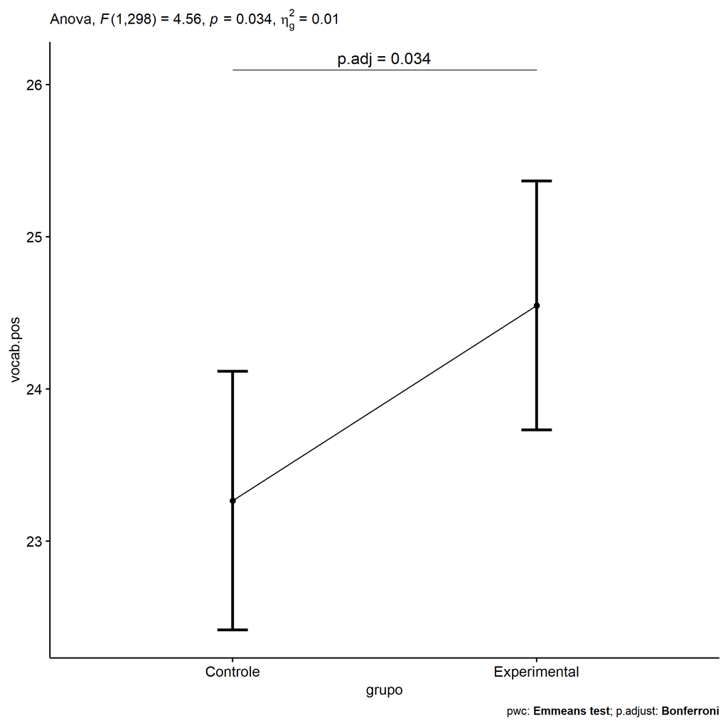

```r
if (!is.null(nrow(plots[["grupo"]]$data)))
  plots[["grupo"]] + ggplot2::scale_color_manual(values = color[["grupo"]])
```

```r
plots <- oneWayAncovaBoxPlots(
  wdat, "vocab.pos", "grupo", aov, pwc, covar = "vocab.pre",
  theme = "classic", color = color[["grupo"]],
  subtitle = which(aov$Effect == "grupo"))
```

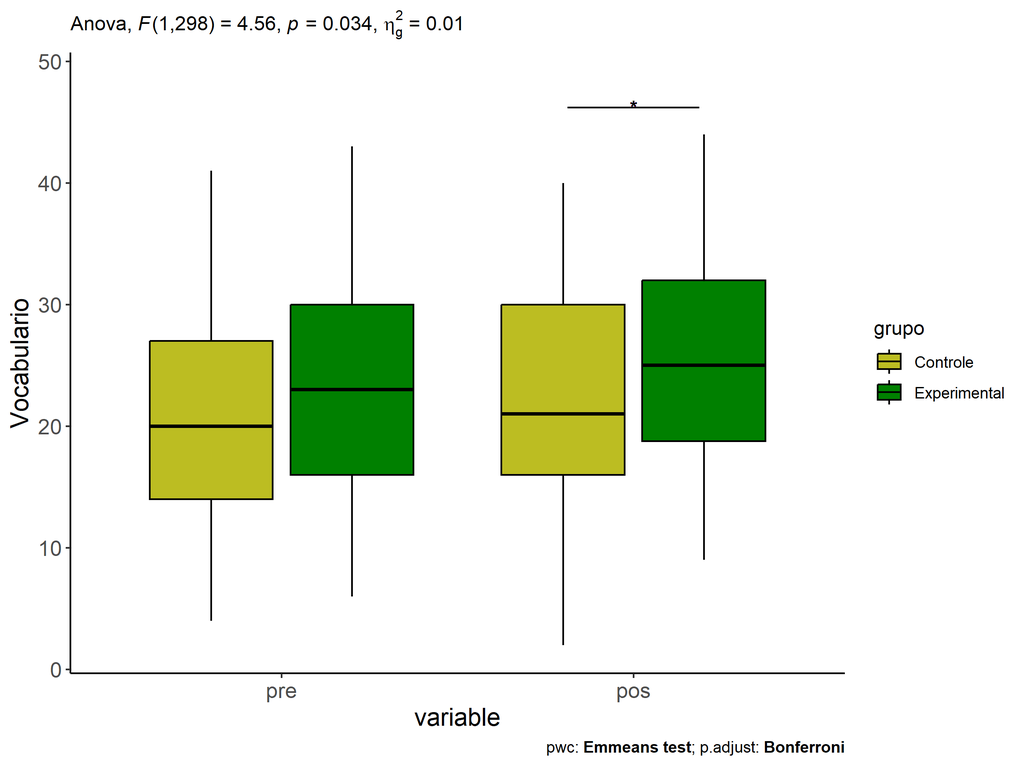

```r
if (length(unique(wdat[["grupo"]])) > 1)
  plots[["grupo"]] + ggplot2::ylab("Vocabulario") + ggplot2::scale_x_discrete(labels=c('pre', 'pos'))
```

```r
if (length(unique(wdat.long[["grupo"]])) > 1)
  plots <- oneWayAncovaBoxPlots(
    wdat.long, "vocab", "grupo", aov, pwc.long, pre.post = "time",
    theme = "classic", color = color$prepost)
```

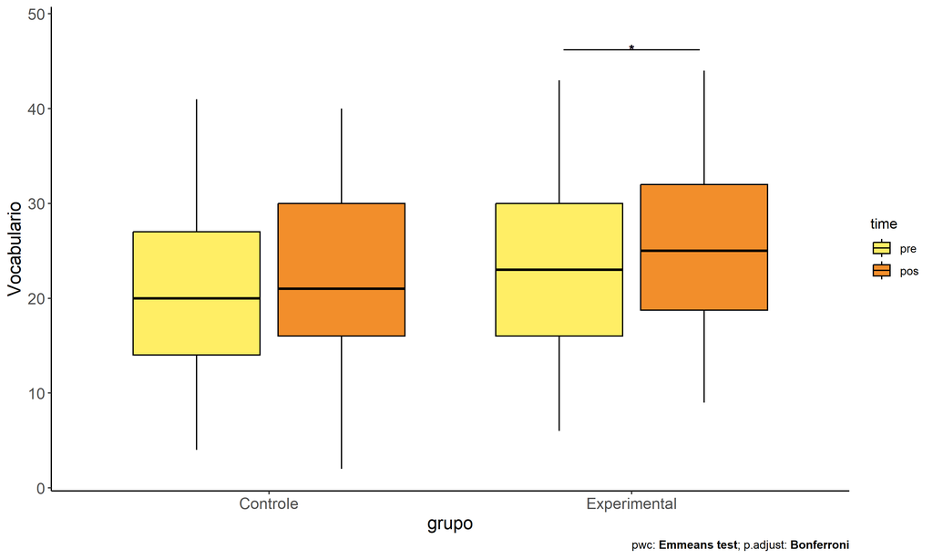

```r
if (length(unique(wdat.long[["grupo"]])) > 1)
  plots[["grupo"]] + ggplot2::ylab("Vocabulario")
```

### Checking linearity assumption

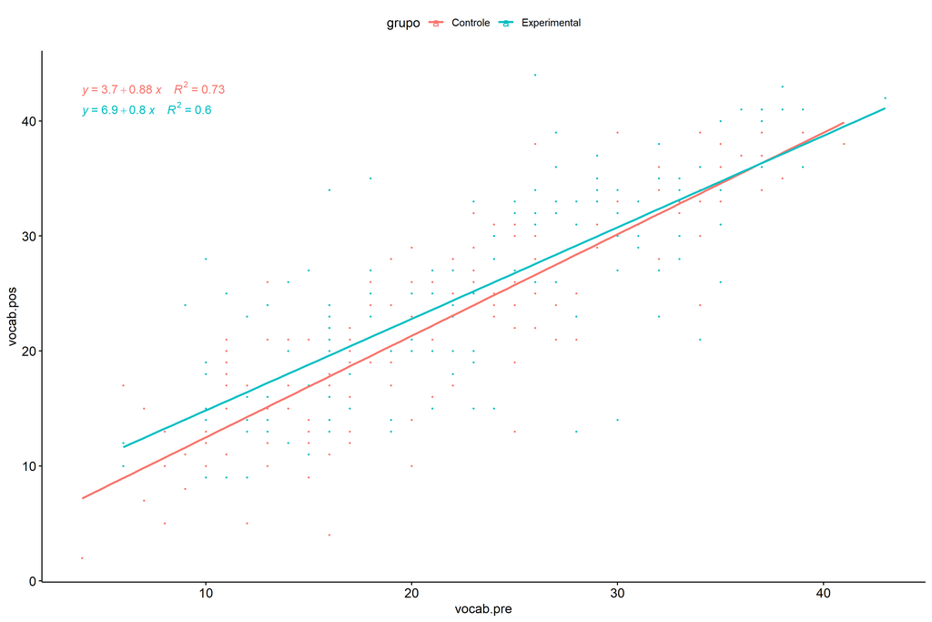

```r
ggscatter(wdat, x = "vocab.pre", y = "vocab.pos", size = 0.5,
          color = "grupo", add = "reg.line")+
  stat_regline_equation(
    aes(label =  paste(..eq.label.., ..rr.label.., sep = "~~~~"), color = grupo)
  )
```

### Checking normality and homogeneity

```r
res <- augment(lm(vocab.pos ~ vocab.pre + grupo, data = wdat))
```

```r
shapiro_test(res$.resid)
```

```
## # A tibble: 1 × 3
##   variable   statistic p.value
##   <chr>          <dbl>   <dbl>
## 1 res$.resid     0.991  0.0637
```

```r
levene_test(res, .resid ~ grupo)
```

```
## # A tibble: 1 × 4
##     df1   df2 statistic      p
##   <int> <int>     <dbl>  <dbl>
## 1     1   299      2.73 0.0993
```

# ANCOVA and Pairwise for two factors **grupo:Sexo**

## Without remove non-normal data

```r
pdat = remove_group_data(dat[!is.na(dat[["grupo"]]) & !is.na(dat[["Sexo"]]),], "vocab.pos", c("grupo","Sexo"))

pdat.long <- rbind(pdat[,c("id","grupo","Sexo")], pdat[,c("id","grupo","Sexo")])
pdat.long[["time"]] <- c(rep("pre", nrow(pdat)), rep("pos", nrow(pdat)))
pdat.long[["time"]] <- factor(pdat.long[["time"]], c("pre","pos"))
pdat.long[["vocab"]] <- c(pdat[["vocab.pre"]], pdat[["vocab.pos"]])

aov = anova_test(pdat, vocab.pos ~ vocab.pre + grupo*Sexo)
laov[["grupo:Sexo"]] <- get_anova_table(aov)
```

```r
pwcs <- list()
pwcs[["Sexo"]] <- emmeans_test(
  group_by(pdat, grupo), vocab.pos ~ Sexo,
  covariate = vocab.pre, p.adjust.method = "bonferroni")
pwcs[["grupo"]] <- emmeans_test(
  group_by(pdat, Sexo), vocab.pos ~ grupo,
  covariate = vocab.pre, p.adjust.method = "bonferroni")

pwc <- plyr::rbind.fill(pwcs[["grupo"]], pwcs[["Sexo"]])
pwc <- pwc[,c("grupo","Sexo", colnames(pwc)[!colnames(pwc) %in% c("grupo","Sexo")])]
```

```r
pwc.long <- emmeans_test(dplyr::group_by_at(pdat.long, c("grupo","Sexo")),
                         vocab ~ time,
                         p.adjust.method = "bonferroni")
lpwc[["grupo:Sexo"]] <- plyr::rbind.fill(pwc, pwc.long)
```

```r
ds <- get.descriptives(pdat, "vocab.pos", c("grupo","Sexo"), covar = "vocab.pre")
ds <- merge(ds[ds$variable != "vocab.pre",],
            ds[ds$variable == "vocab.pre", !colnames(ds) %in% c("variable")],
            by = c("grupo","Sexo"), all.x = T, suffixes = c("", ".vocab.pre"))
ds <- merge(get_emmeans(pwcs[["grupo"]]), ds, by = c("grupo","Sexo"), suffixes = c(".emms", ""))
ds <- ds[,c("grupo","Sexo","n","mean.vocab.pre","se.vocab.pre","mean","se","emmean","se.emms")]

colnames(ds) <- c("grupo","Sexo", "N", paste0(c("M","SE")," (pre)"),
                  paste0(c("M","SE"), " (unadj)"), paste0(c("M", "SE"), " (adj)"))

lemms[["grupo:Sexo"]] <- ds
```

```r
wdat = pdat

res = residuals(lm(vocab.pos ~ vocab.pre + grupo*Sexo, data = wdat))
non.normal = getNonNormal(res, wdat$id, plimit = 0.05)

wdat = wdat[!wdat$id %in% non.normal,]

wdat.long <- rbind(wdat[,c("id","grupo","Sexo")], wdat[,c("id","grupo","Sexo")])
wdat.long[["time"]] <- c(rep("pre", nrow(wdat)), rep("pos", nrow(wdat)))
wdat.long[["time"]] <- factor(wdat.long[["time"]], c("pre","pos"))
wdat.long[["vocab"]] <- c(wdat[["vocab.pre"]], wdat[["vocab.pos"]])


ldat[["grupo:Sexo"]] = wdat

(non.normal)
```

```
## [1] "P852"  "P1790" "P2850" "P478"  "P1620" "P863"  "P489"  "P3473" "P887"
```

```r
aov = anova_test(wdat, vocab.pos ~ vocab.pre + grupo*Sexo)
laov[["grupo:Sexo"]] <- merge(get_anova_table(aov), laov[["grupo:Sexo"]], by="Effect", suffixes = c("","'"))

(df = get_anova_table(aov))
```

```
## ANOVA Table (type II tests)
##
##       Effect DFn DFd       F        p p<.05      ges
## 1  vocab.pre   1 297 530.592 4.67e-68     * 0.641000
## 2      grupo   1 297   3.248 7.30e-02       0.011000
## 3       Sexo   1 297  10.260 2.00e-03     * 0.033000
## 4 grupo:Sexo   1 297   0.203 6.52e-01       0.000684
```

| Effect | DFn | DFd | F | p | p<.05 | ges |
| --- | --- | --- | --- | --- | --- | --- |
| vocab.pre | 1 | 297 | 530.592 | 0.000 | * | 0.641 |
| grupo | 1 | 297 | 3.248 | 0.073 |  | 0.011 |
| Sexo | 1 | 297 | 10.260 | 0.002 | * | 0.033 |
| grupo:Sexo | 1 | 297 | 0.203 | 0.652 |  | 0.001 |

```r
pwcs <- list()
pwcs[["Sexo"]] <- emmeans_test(
  group_by(wdat, grupo), vocab.pos ~ Sexo,
  covariate = vocab.pre, p.adjust.method = "bonferroni")
pwcs[["grupo"]] <- emmeans_test(
  group_by(wdat, Sexo), vocab.pos ~ grupo,
  covariate = vocab.pre, p.adjust.method = "bonferroni")

pwc <- plyr::rbind.fill(pwcs[["grupo"]], pwcs[["Sexo"]])
pwc <- pwc[,c("grupo","Sexo", colnames(pwc)[!colnames(pwc) %in% c("grupo","Sexo")])]
```

| grupo | Sexo | term | .y. | group1 | group2 | df | statistic | p | p.adj | p.adj.signif |
| --- | --- | --- | --- | --- | --- | --- | --- | --- | --- | --- |
|  | F | vocab.pre*grupo | vocab.pos | Controle | Experimental | 297 | -0.932 | 0.352 | 0.352 | ns |
|  | M | vocab.pre*grupo | vocab.pos | Controle | Experimental | 297 | -1.611 | 0.108 | 0.108 | ns |
| Controle |  | vocab.pre*Sexo | vocab.pos | F | M | 297 | 2.552 | 0.011 | 0.011 | * |
| Experimental |  | vocab.pre*Sexo | vocab.pos | F | M | 297 | 2.021 | 0.044 | 0.044 | * |

```r
pwc.long <- emmeans_test(dplyr::group_by_at(wdat.long, c("grupo","Sexo")),
                         vocab ~ time,
                         p.adjust.method = "bonferroni")
lpwc[["grupo:Sexo"]] <- merge(plyr::rbind.fill(pwc, pwc.long), lpwc[["grupo:Sexo"]], by=c("grupo","Sexo","term",".y.","group1","group2"), suffixes = c("","'"))
```

| grupo | Sexo | term | .y. | group1 | group2 | df | statistic | p | p.adj | p.adj.signif |
| --- | --- | --- | --- | --- | --- | --- | --- | --- | --- | --- |
| Controle | F | time | vocab | pre | pos | 596 | -1.381 | 0.168 | 0.168 | ns |
| Controle | M | time | vocab | pre | pos | 596 | -0.302 | 0.763 | 0.763 | ns |
| Experimental | F | time | vocab | pre | pos | 596 | -1.964 | 0.050 | 0.050 | ns |
| Experimental | M | time | vocab | pre | pos | 596 | -1.026 | 0.306 | 0.306 | ns |

```r
ds <- get.descriptives(wdat, "vocab.pos", c("grupo","Sexo"), covar = "vocab.pre")
ds <- merge(ds[ds$variable != "vocab.pre",],
            ds[ds$variable == "vocab.pre", !colnames(ds) %in% c("variable")],
            by = c("grupo","Sexo"), all.x = T, suffixes = c("", ".vocab.pre"))
ds <- merge(get_emmeans(pwcs[["grupo"]]), ds, by = c("grupo","Sexo"), suffixes = c(".emms", ""))
ds <- ds[,c("grupo","Sexo","n","mean.vocab.pre","se.vocab.pre","mean","se","emmean","se.emms")]

colnames(ds) <- c("grupo","Sexo", "N", paste0(c("M","SE")," (pre)"),
                  paste0(c("M","SE"), " (unadj)"), paste0(c("M", "SE"), " (adj)"))

lemms[["grupo:Sexo"]] <- merge(ds, lemms[["grupo:Sexo"]], by=c("grupo","Sexo"), suffixes = c("","'"))
```

| grupo | Sexo | N | M (pre) | SE (pre) | M (unadj) | SE (unadj) | M (adj) | SE (adj) |
| --- | --- | --- | --- | --- | --- | --- | --- | --- |
| Controle | F | 64 | 22.953 | 1.037 | 25.047 | 1.011 | 24.528 | 0.647 |
| Controle | M | 81 | 20.148 | 0.978 | 20.556 | 1.011 | 22.306 | 0.580 |
| Experimental | F | 83 | 24.434 | 0.954 | 27.048 | 0.958 | 25.331 | 0.573 |
| Experimental | M | 74 | 21.743 | 0.959 | 23.189 | 0.977 | 23.649 | 0.602 |

### Plots for ancova

```r
plots <- twoWayAncovaPlots(
  wdat, "vocab.pos", c("grupo","Sexo"), aov, pwcs, addParam = c("mean_se"),
  font.label.size=10, step.increase=0.05, p.label="p.adj",
  subtitle = which(aov$Effect == "grupo:Sexo"))
```

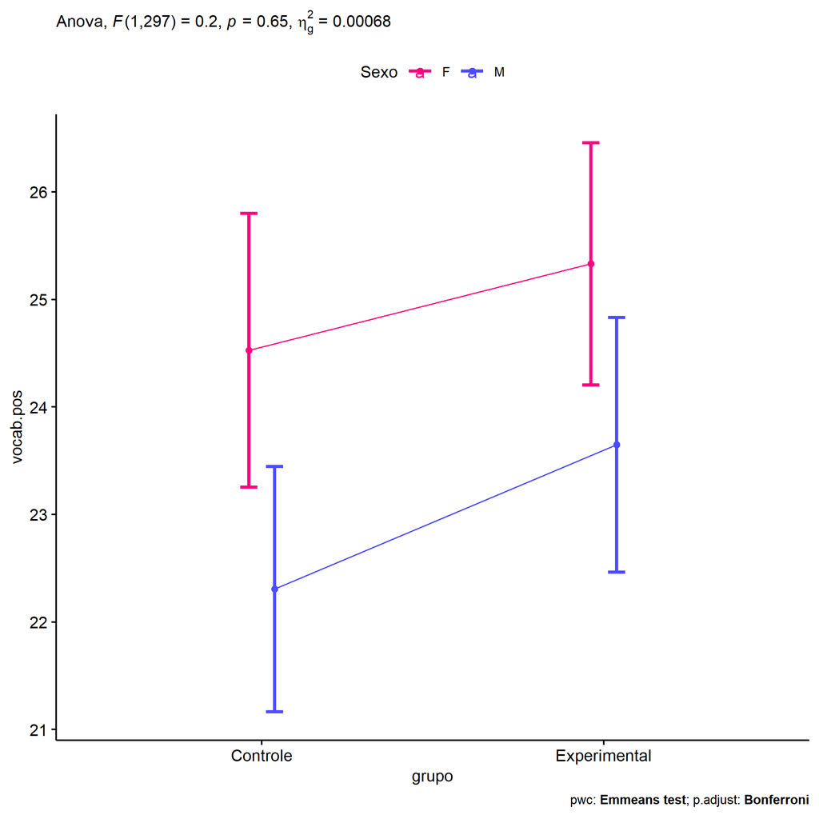

```r
if (!is.null(plots[["grupo"]]))
  plots[["grupo"]] + ggplot2::scale_color_manual(values = color[["Sexo"]])
```

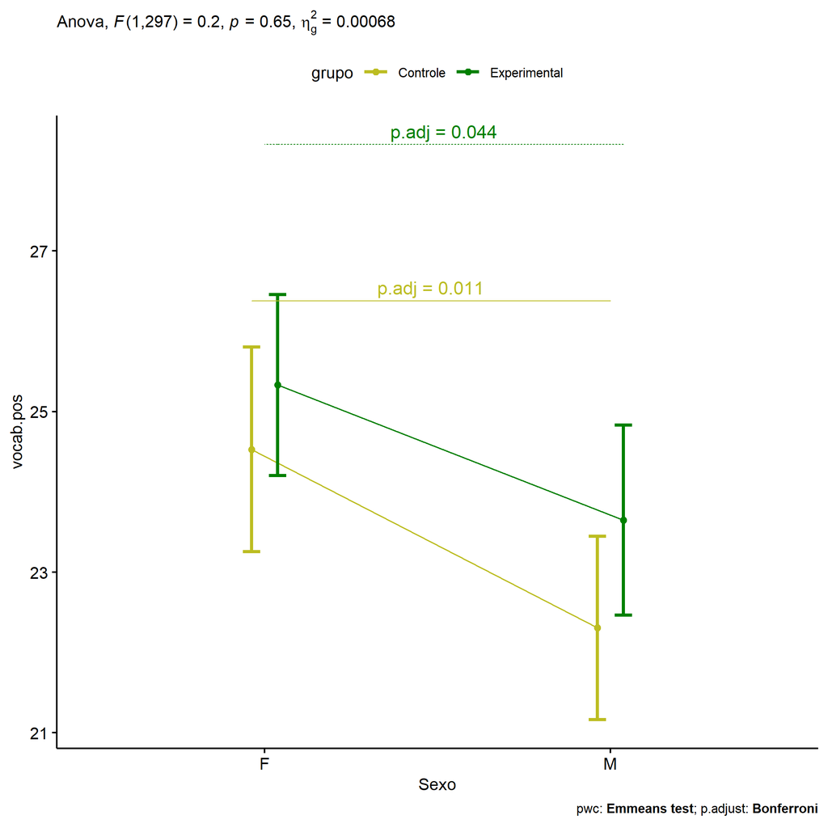

```r
if (!is.null(plots[["Sexo"]]))
  plots[["Sexo"]] + ggplot2::scale_color_manual(values = color[["grupo"]])
```

```r
plots <- twoWayAncovaBoxPlots(
  wdat, "vocab.pos", c("grupo","Sexo"), aov, pwcs, covar = "vocab.pre",
  theme = "classic", color = color[["grupo:Sexo"]],
  subtitle = which(aov$Effect == "grupo:Sexo"))
```

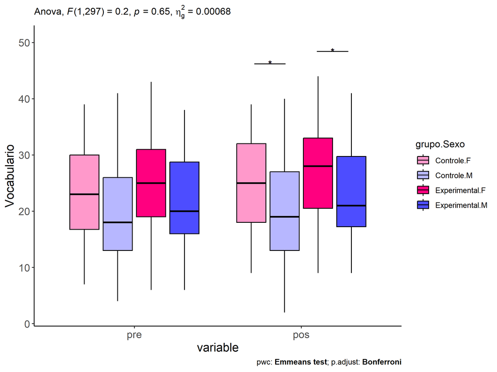

```r
plots[["grupo:Sexo"]] + ggplot2::ylab("Vocabulario") + ggplot2::scale_x_discrete(labels=c('pre', 'pos'))
```

```r
plots <- twoWayAncovaBoxPlots(
  wdat.long, "vocab", c("grupo","Sexo"), aov, pwc.long, pre.post = "time",
  theme = "classic", color = color$prepost)
```

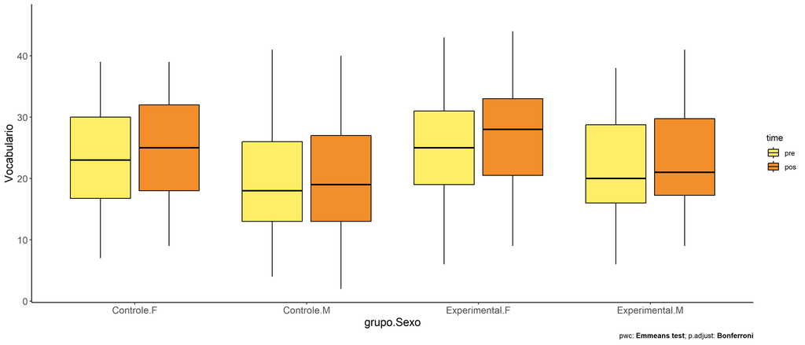

```r
plots[["grupo:Sexo"]] + ggplot2::ylab("Vocabulario")
```

### Checking linearity assumption

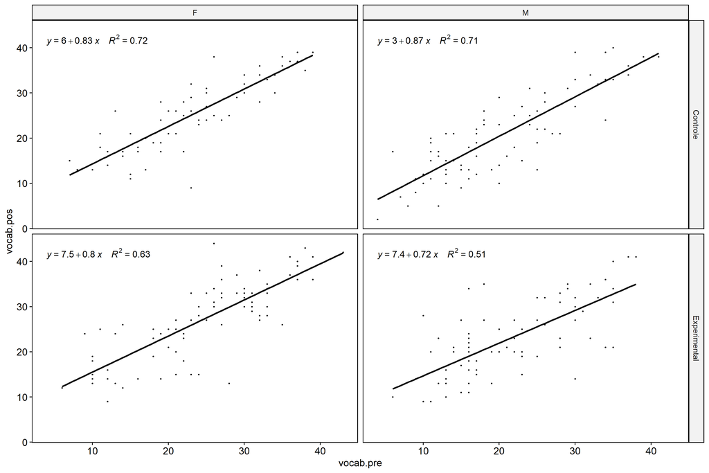

```r
ggscatter(wdat, x = "vocab.pre", y = "vocab.pos", size = 0.5,
          facet.by = c("grupo","Sexo"), add = "reg.line")+
  stat_regline_equation(
    aes(label =  paste(..eq.label.., ..rr.label.., sep = "~~~~"))
  )
```

### Checking normality and homogeneity

```r
res <- augment(lm(vocab.pos ~ vocab.pre + grupo*Sexo, data = wdat))
```

```r
shapiro_test(res$.resid)
```

```
## # A tibble: 1 × 3
##   variable   statistic p.value
##   <chr>          <dbl>   <dbl>
## 1 res$.resid     0.990  0.0437
```

```r
levene_test(res, .resid ~ grupo*Sexo)
```

```
## # A tibble: 1 × 4
##     df1   df2 statistic      p
##   <int> <int>     <dbl>  <dbl>
## 1     3   298      2.31 0.0764
```

# ANCOVA and Pairwise for two factors **grupo:Zona**

## Without remove non-normal data

```r
pdat = remove_group_data(dat[!is.na(dat[["grupo"]]) & !is.na(dat[["Zona"]]),], "vocab.pos", c("grupo","Zona"))

pdat.long <- rbind(pdat[,c("id","grupo","Zona")], pdat[,c("id","grupo","Zona")])
pdat.long[["time"]] <- c(rep("pre", nrow(pdat)), rep("pos", nrow(pdat)))
pdat.long[["time"]] <- factor(pdat.long[["time"]], c("pre","pos"))
pdat.long[["vocab"]] <- c(pdat[["vocab.pre"]], pdat[["vocab.pos"]])

aov = anova_test(pdat, vocab.pos ~ vocab.pre + grupo*Zona)
laov[["grupo:Zona"]] <- get_anova_table(aov)
```

```r
pwcs <- list()
pwcs[["Zona"]] <- emmeans_test(
  group_by(pdat, grupo), vocab.pos ~ Zona,
  covariate = vocab.pre, p.adjust.method = "bonferroni")
pwcs[["grupo"]] <- emmeans_test(
  group_by(pdat, Zona), vocab.pos ~ grupo,
  covariate = vocab.pre, p.adjust.method = "bonferroni")

pwc <- plyr::rbind.fill(pwcs[["grupo"]], pwcs[["Zona"]])
pwc <- pwc[,c("grupo","Zona", colnames(pwc)[!colnames(pwc) %in% c("grupo","Zona")])]
```

```r
pwc.long <- emmeans_test(dplyr::group_by_at(pdat.long, c("grupo","Zona")),
                         vocab ~ time,
                         p.adjust.method = "bonferroni")
lpwc[["grupo:Zona"]] <- plyr::rbind.fill(pwc, pwc.long)
```

```r
ds <- get.descriptives(pdat, "vocab.pos", c("grupo","Zona"), covar = "vocab.pre")
ds <- merge(ds[ds$variable != "vocab.pre",],
            ds[ds$variable == "vocab.pre", !colnames(ds) %in% c("variable")],
            by = c("grupo","Zona"), all.x = T, suffixes = c("", ".vocab.pre"))
ds <- merge(get_emmeans(pwcs[["grupo"]]), ds, by = c("grupo","Zona"), suffixes = c(".emms", ""))
ds <- ds[,c("grupo","Zona","n","mean.vocab.pre","se.vocab.pre","mean","se","emmean","se.emms")]

colnames(ds) <- c("grupo","Zona", "N", paste0(c("M","SE")," (pre)"),
                  paste0(c("M","SE"), " (unadj)"), paste0(c("M", "SE"), " (adj)"))

lemms[["grupo:Zona"]] <- ds
```

## Computing ANCOVA and PairWise After removing non-normal data (OK)

```r
wdat = pdat

res = residuals(lm(vocab.pos ~ vocab.pre + grupo*Zona, data = wdat))
non.normal = getNonNormal(res, wdat$id, plimit = 0.05)

wdat = wdat[!wdat$id %in% non.normal,]

wdat.long <- rbind(wdat[,c("id","grupo","Zona")], wdat[,c("id","grupo","Zona")])
wdat.long[["time"]] <- c(rep("pre", nrow(wdat)), rep("pos", nrow(wdat)))
wdat.long[["time"]] <- factor(wdat.long[["time"]], c("pre","pos"))
wdat.long[["vocab"]] <- c(wdat[["vocab.pre"]], wdat[["vocab.pos"]])


ldat[["grupo:Zona"]] = wdat

(non.normal)
```

```
## [1] "P852"  "P478"  "P863"  "P2850" "P887"  "P3473" "P888"
```

```r
aov = anova_test(wdat, vocab.pos ~ vocab.pre + grupo*Zona)
laov[["grupo:Zona"]] <- merge(get_anova_table(aov), laov[["grupo:Zona"]], by="Effect", suffixes = c("","'"))

(df = get_anova_table(aov))
```

```
## ANOVA Table (type II tests)
##
##       Effect DFn DFd       F        p p<.05      ges
## 1  vocab.pre   1 236 446.913 2.26e-56     * 6.54e-01
## 2      grupo   1 236   1.633 2.03e-01       7.00e-03
## 3       Zona   1 236   0.789 3.75e-01       3.00e-03
## 4 grupo:Zona   1 236   0.002 9.67e-01       7.10e-06
```

| Effect | DFn | DFd | F | p | p<.05 | ges |
| --- | --- | --- | --- | --- | --- | --- |
| vocab.pre | 1 | 236 | 446.913 | 0.000 | * | 0.654 |
| grupo | 1 | 236 | 1.633 | 0.203 |  | 0.007 |
| Zona | 1 | 236 | 0.789 | 0.375 |  | 0.003 |
| grupo:Zona | 1 | 236 | 0.002 | 0.967 |  | 0.000 |

```r
pwcs <- list()
pwcs[["Zona"]] <- emmeans_test(
  group_by(wdat, grupo), vocab.pos ~ Zona,
  covariate = vocab.pre, p.adjust.method = "bonferroni")
pwcs[["grupo"]] <- emmeans_test(
  group_by(wdat, Zona), vocab.pos ~ grupo,
  covariate = vocab.pre, p.adjust.method = "bonferroni")

pwc <- plyr::rbind.fill(pwcs[["grupo"]], pwcs[["Zona"]])
pwc <- pwc[,c("grupo","Zona", colnames(pwc)[!colnames(pwc) %in% c("grupo","Zona")])]
```

| grupo | Zona | term | .y. | group1 | group2 | df | statistic | p | p.adj | p.adj.signif |
| --- | --- | --- | --- | --- | --- | --- | --- | --- | --- | --- |
|  | Rural | vocab.pre*grupo | vocab.pos | Controle | Experimental | 236 | -1.115 | 0.266 | 0.266 | ns |
|  | Urbana | vocab.pre*grupo | vocab.pos | Controle | Experimental | 236 | -0.625 | 0.532 | 0.532 | ns |
| Controle |  | vocab.pre*Zona | vocab.pos | Rural | Urbana | 236 | -0.634 | 0.526 | 0.526 | ns |
| Experimental |  | vocab.pre*Zona | vocab.pos | Rural | Urbana | 236 | -0.625 | 0.532 | 0.532 | ns |

```r
pwc.long <- emmeans_test(dplyr::group_by_at(wdat.long, c("grupo","Zona")),
                         vocab ~ time,
                         p.adjust.method = "bonferroni")
lpwc[["grupo:Zona"]] <- merge(plyr::rbind.fill(pwc, pwc.long), lpwc[["grupo:Zona"]], by=c("grupo","Zona","term",".y.","group1","group2"), suffixes = c("","'"))
```

| grupo | Zona | term | .y. | group1 | group2 | df | statistic | p | p.adj | p.adj.signif |
| --- | --- | --- | --- | --- | --- | --- | --- | --- | --- | --- |
| Controle | Rural | time | vocab | pre | pos | 474 | -0.858 | 0.391 | 0.391 | ns |
| Controle | Urbana | time | vocab | pre | pos | 474 | -0.691 | 0.490 | 0.490 | ns |
| Experimental | Rural | time | vocab | pre | pos | 474 | -1.453 | 0.147 | 0.147 | ns |
| Experimental | Urbana | time | vocab | pre | pos | 474 | -1.108 | 0.268 | 0.268 | ns |

```r
ds <- get.descriptives(wdat, "vocab.pos", c("grupo","Zona"), covar = "vocab.pre")
ds <- merge(ds[ds$variable != "vocab.pre",],
            ds[ds$variable == "vocab.pre", !colnames(ds) %in% c("variable")],
            by = c("grupo","Zona"), all.x = T, suffixes = c("", ".vocab.pre"))
ds <- merge(get_emmeans(pwcs[["grupo"]]), ds, by = c("grupo","Zona"), suffixes = c(".emms", ""))
ds <- ds[,c("grupo","Zona","n","mean.vocab.pre","se.vocab.pre","mean","se","emmean","se.emms")]

colnames(ds) <- c("grupo","Zona", "N", paste0(c("M","SE")," (pre)"),
                  paste0(c("M","SE"), " (unadj)"), paste0(c("M", "SE"), " (adj)"))

lemms[["grupo:Zona"]] <- merge(ds, lemms[["grupo:Zona"]], by=c("grupo","Zona"), suffixes = c("","'"))
```

| grupo | Zona | N | M (pre) | SE (pre) | M (unadj) | SE (unadj) | M (adj) | SE (adj) |
| --- | --- | --- | --- | --- | --- | --- | --- | --- |
| Controle | Rural | 95 | 22.189 | 0.859 | 23.274 | 0.928 | 23.575 | 0.531 |
| Controle | Urbana | 28 | 23.214 | 1.905 | 24.821 | 1.646 | 24.281 | 0.977 |
| Experimental | Rural | 81 | 22.012 | 0.926 | 24.000 | 0.898 | 24.447 | 0.575 |
| Experimental | Urbana | 37 | 24.189 | 1.450 | 26.432 | 1.571 | 25.090 | 0.852 |

### Plots for ancova

```r
plots <- twoWayAncovaPlots(
  wdat, "vocab.pos", c("grupo","Zona"), aov, pwcs, addParam = c("mean_se"),
  font.label.size=10, step.increase=0.05, p.label="p.adj",
  subtitle = which(aov$Effect == "grupo:Zona"))
```

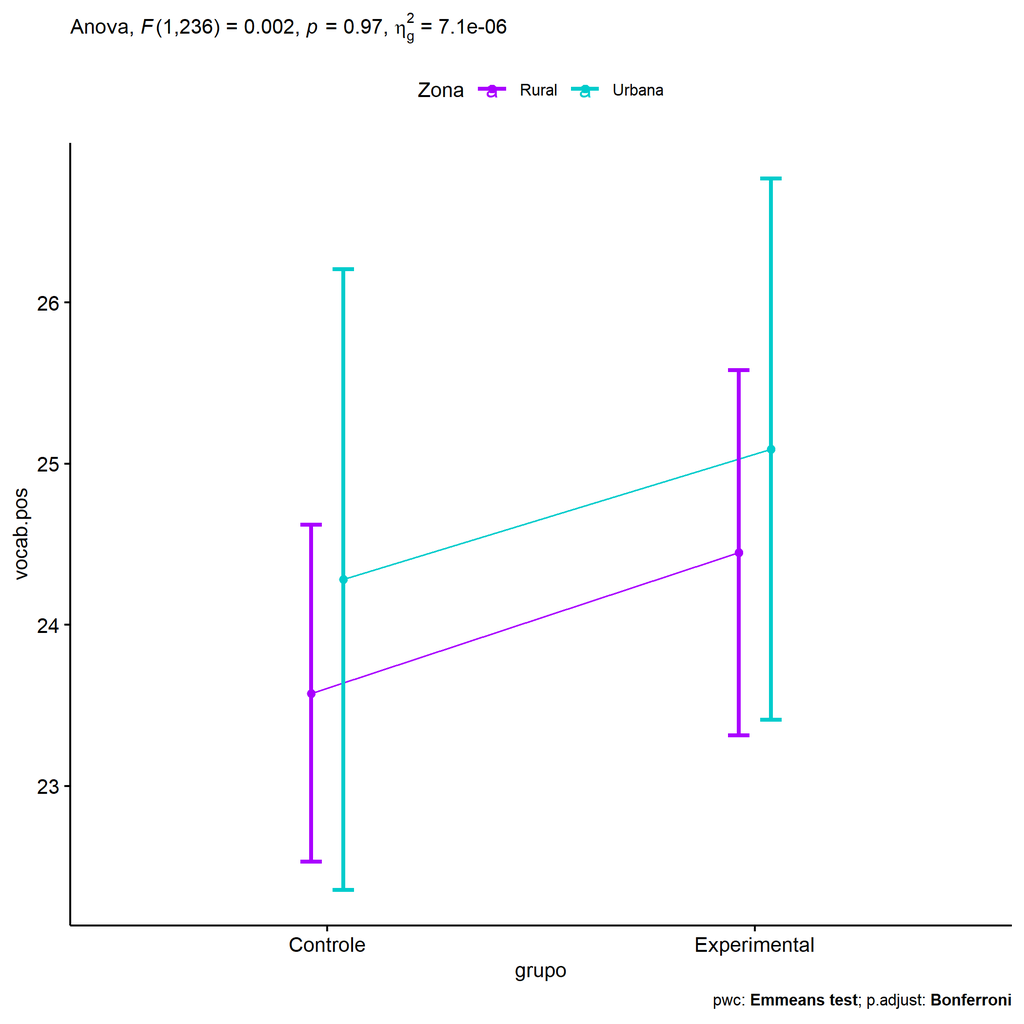

```r
if (!is.null(plots[["grupo"]]))
  plots[["grupo"]] + ggplot2::scale_color_manual(values = color[["Zona"]])
```

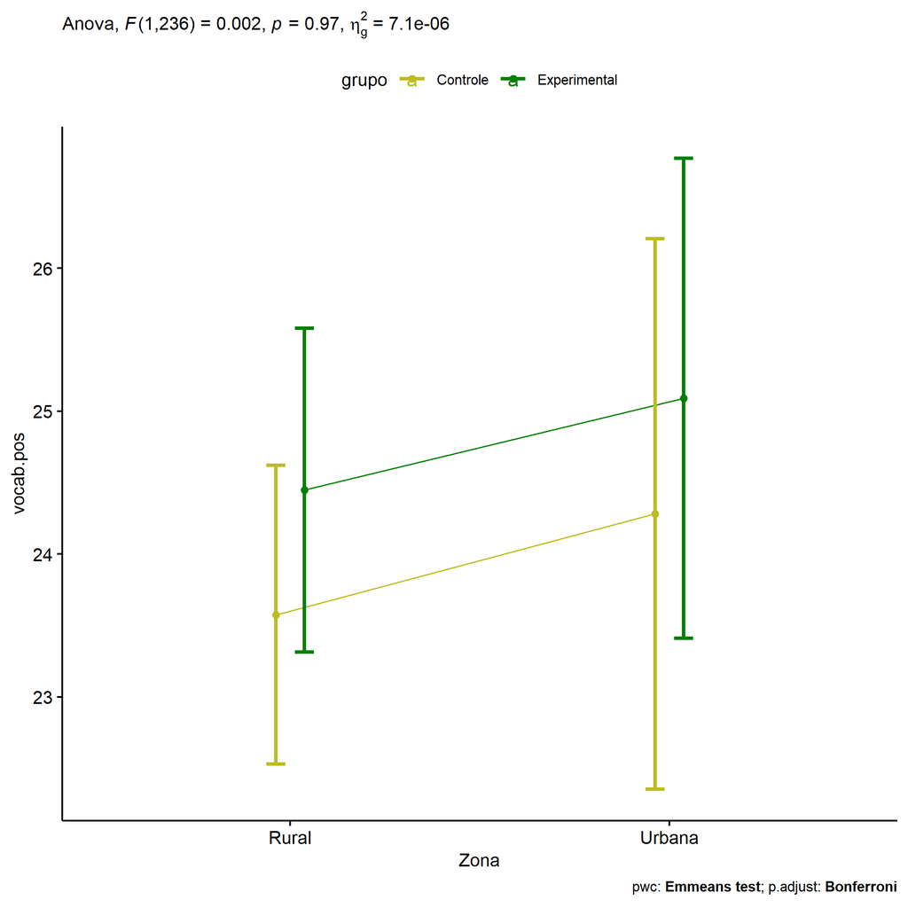

```r
if (!is.null(plots[["Zona"]]))
  plots[["Zona"]] + ggplot2::scale_color_manual(values = color[["grupo"]])
```

```r
plots <- twoWayAncovaBoxPlots(
  wdat, "vocab.pos", c("grupo","Zona"), aov, pwcs, covar = "vocab.pre",
  theme = "classic", color = color[["grupo:Zona"]],
  subtitle = which(aov$Effect == "grupo:Zona"))
```

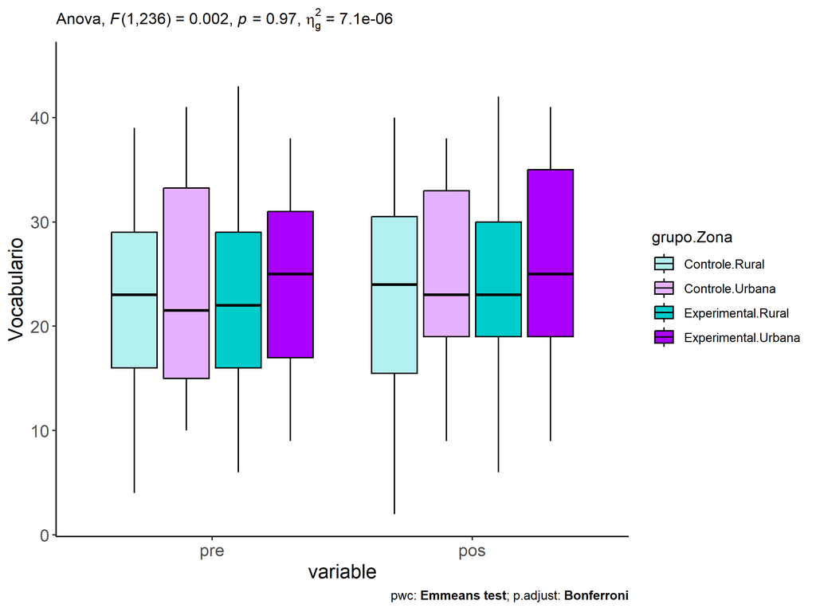

```r
plots[["grupo:Zona"]] + ggplot2::ylab("Vocabulario") + ggplot2::scale_x_discrete(labels=c('pre', 'pos'))
```

```r
plots <- twoWayAncovaBoxPlots(
  wdat.long, "vocab", c("grupo","Zona"), aov, pwc.long, pre.post = "time",
  theme = "classic", color = color$prepost)
```

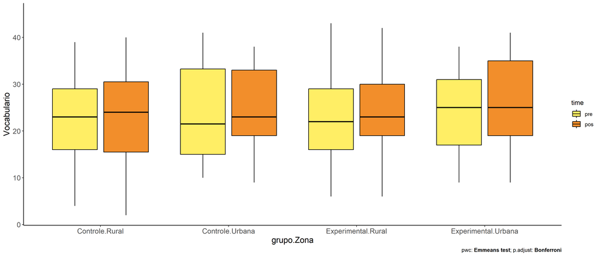

```r
plots[["grupo:Zona"]] + ggplot2::ylab("Vocabulario")
```

### Checking linearity assumption

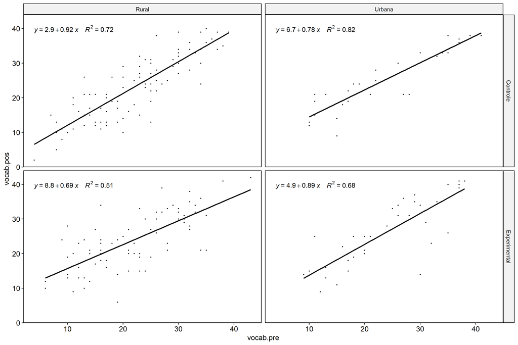

```r
ggscatter(wdat, x = "vocab.pre", y = "vocab.pos", size = 0.5,
          facet.by = c("grupo","Zona"), add = "reg.line")+
  stat_regline_equation(
    aes(label =  paste(..eq.label.., ..rr.label.., sep = "~~~~"))
  )
```

### Checking normality and homogeneity

```r
res <- augment(lm(vocab.pos ~ vocab.pre + grupo*Zona, data = wdat))
```

```r
shapiro_test(res$.resid)
```

```
## # A tibble: 1 × 3
##   variable   statistic p.value
##   <chr>          <dbl>   <dbl>
## 1 res$.resid     0.989  0.0614
```

```r
levene_test(res, .resid ~ grupo*Zona)
```

```
## # A tibble: 1 × 4
##     df1   df2 statistic     p
##   <int> <int>     <dbl> <dbl>
## 1     3   237      1.77 0.153
```

# ANCOVA and Pairwise for two factors **grupo:Cor.Raca**

## Without remove non-normal data

```r
pdat = remove_group_data(dat[!is.na(dat[["grupo"]]) & !is.na(dat[["Cor.Raca"]]),], "vocab.pos", c("grupo","Cor.Raca"))
pdat.long <- rbind(pdat[,c("id","grupo","Cor.Raca")], pdat[,c("id","grupo","Cor.Raca")])
pdat.long[["time"]] <- c(rep("pre", nrow(pdat)), rep("pos", nrow(pdat)))
pdat.long[["time"]] <- factor(pdat.long[["time"]], c("pre","pos"))
pdat.long[["vocab"]] <- c(pdat[["vocab.pre"]], pdat[["vocab.pos"]])

aov = anova_test(pdat, vocab.pos ~ vocab.pre + grupo*Cor.Raca)
laov[["grupo:Cor.Raca"]] <- get_anova_table(aov)
```

```r
pwcs <- list()
pwcs[["Cor.Raca"]] <- emmeans_test(
  group_by(pdat, grupo), vocab.pos ~ Cor.Raca,
  covariate = vocab.pre, p.adjust.method = "bonferroni")
pwcs[["grupo"]] <- emmeans_test(
  group_by(pdat, Cor.Raca), vocab.pos ~ grupo,
  covariate = vocab.pre, p.adjust.method = "bonferroni")

pwc <- plyr::rbind.fill(pwcs[["grupo"]], pwcs[["Cor.Raca"]])
pwc <- pwc[,c("grupo","Cor.Raca", colnames(pwc)[!colnames(pwc) %in% c("grupo","Cor.Raca")])]
```

```r
pwc.long <- emmeans_test(dplyr::group_by_at(pdat.long, c("grupo","Cor.Raca")),
                         vocab ~ time,
                         p.adjust.method = "bonferroni")
lpwc[["grupo:Cor.Raca"]] <- plyr::rbind.fill(pwc, pwc.long)
```

```r
ds <- get.descriptives(pdat, "vocab.pos", c("grupo","Cor.Raca"), covar = "vocab.pre")
ds <- merge(ds[ds$variable != "vocab.pre",],
            ds[ds$variable == "vocab.pre", !colnames(ds) %in% c("variable")],
            by = c("grupo","Cor.Raca"), all.x = T, suffixes = c("", ".vocab.pre"))
ds <- merge(get_emmeans(pwcs[["grupo"]]), ds, by = c("grupo","Cor.Raca"), suffixes = c(".emms", ""))
ds <- ds[,c("grupo","Cor.Raca","n","mean.vocab.pre","se.vocab.pre","mean","se","emmean","se.emms")]

colnames(ds) <- c("grupo","Cor.Raca", "N", paste0(c("M","SE")," (pre)"),
                  paste0(c("M","SE"), " (unadj)"), paste0(c("M", "SE"), " (adj)"))

lemms[["grupo:Cor.Raca"]] <- ds
```

## Computing ANCOVA and PairWise After removing non-normal data (OK)

```r
wdat = pdat

res = residuals(lm(vocab.pos ~ vocab.pre + grupo*Cor.Raca, data = wdat))
non.normal = getNonNormal(res, wdat$id, plimit = 0.05)

wdat = wdat[!wdat$id %in% non.normal,]

wdat.long <- rbind(wdat[,c("id","grupo","Cor.Raca")], wdat[,c("id","grupo","Cor.Raca")])
wdat.long[["time"]] <- c(rep("pre", nrow(wdat)), rep("pos", nrow(wdat)))
wdat.long[["time"]] <- factor(wdat.long[["time"]], c("pre","pos"))
wdat.long[["vocab"]] <- c(wdat[["vocab.pre"]], wdat[["vocab.pos"]])


ldat[["grupo:Cor.Raca"]] = wdat

(non.normal)
```

```
## [1] "P852"
```

```r
aov = anova_test(wdat, vocab.pos ~ vocab.pre + grupo*Cor.Raca)
laov[["grupo:Cor.Raca"]] <- merge(get_anova_table(aov), laov[["grupo:Cor.Raca"]], by="Effect", suffixes = c("","'"))

(df = get_anova_table(aov))
```

```
## ANOVA Table (type II tests)
##
##           Effect DFn DFd       F        p p<.05   ges
## 1      vocab.pre   1 132 261.556 4.12e-33     * 0.665
## 2          grupo   1 132   0.198 6.57e-01       0.001
## 3       Cor.Raca   2 132   1.470 2.34e-01       0.022
## 4 grupo:Cor.Raca   1 132   2.156 1.44e-01       0.016
```

| Effect | DFn | DFd | F | p | p<.05 | ges |
| --- | --- | --- | --- | --- | --- | --- |
| vocab.pre | 1 | 132 | 261.556 | 0.000 | * | 0.665 |
| grupo | 1 | 132 | 0.198 | 0.657 |  | 0.001 |
| Cor.Raca | 2 | 132 | 1.470 | 0.234 |  | 0.022 |
| grupo:Cor.Raca | 1 | 132 | 2.156 | 0.144 |  | 0.016 |

```r
pwcs <- list()
pwcs[["Cor.Raca"]] <- emmeans_test(
  group_by(wdat, grupo), vocab.pos ~ Cor.Raca,
  covariate = vocab.pre, p.adjust.method = "bonferroni")
pwcs[["grupo"]] <- emmeans_test(
  group_by(wdat, Cor.Raca), vocab.pos ~ grupo,
  covariate = vocab.pre, p.adjust.method = "bonferroni")

pwc <- plyr::rbind.fill(pwcs[["grupo"]], pwcs[["Cor.Raca"]])
pwc <- pwc[,c("grupo","Cor.Raca", colnames(pwc)[!colnames(pwc) %in% c("grupo","Cor.Raca")])]
```

| grupo | Cor.Raca | term | .y. | group1 | group2 | df | statistic | p | p.adj | p.adj.signif |
| --- | --- | --- | --- | --- | --- | --- | --- | --- | --- | --- |
|  | Branca | vocab.pre*grupo | vocab.pos | Controle | Experimental | 132 | 0.963 | 0.338 | 0.338 | ns |
|  | Indígena | vocab.pre*grupo | vocab.pos | Controle | Experimental |  |  |  |  |  |
|  | Parda | vocab.pre*grupo | vocab.pos | Controle | Experimental | 132 | -1.192 | 0.235 | 0.235 | ns |
| Controle |  | vocab.pre*Cor.Raca | vocab.pos | Branca | Indígena |  |  |  |  |  |
| Controle |  | vocab.pre*Cor.Raca | vocab.pos | Branca | Parda | 132 | 0.097 | 0.923 | 0.923 | ns |
| Controle |  | vocab.pre*Cor.Raca | vocab.pos | Indígena | Parda |  |  |  |  |  |
| Experimental |  | vocab.pre*Cor.Raca | vocab.pos | Branca | Indígena | 132 | -2.053 | 0.042 | 0.126 | ns |
| Experimental |  | vocab.pre*Cor.Raca | vocab.pos | Branca | Parda | 132 | -1.908 | 0.059 | 0.176 | ns |
| Experimental |  | vocab.pre*Cor.Raca | vocab.pos | Indígena | Parda | 132 | 0.674 | 0.502 | 1.000 | ns |

```r
pwc.long <- emmeans_test(dplyr::group_by_at(wdat.long, c("grupo","Cor.Raca")),
                         vocab ~ time,
                         p.adjust.method = "bonferroni")
lpwc[["grupo:Cor.Raca"]] <- merge(plyr::rbind.fill(pwc, pwc.long), lpwc[["grupo:Cor.Raca"]], by=c("grupo","Cor.Raca","term",".y.","group1","group2"), suffixes = c("","'"))
```

| grupo | Cor.Raca | term | .y. | group1 | group2 | df | statistic | p | p.adj | p.adj.signif |
| --- | --- | --- | --- | --- | --- | --- | --- | --- | --- | --- |
| Controle | Branca | time | vocab | pre | pos | 266 | -0.276 | 0.782 | 0.782 | ns |
| Controle | Indígena | time | vocab | pre | pos |  |  |  |  |  |
| Controle | Parda | time | vocab | pre | pos | 266 | -0.400 | 0.689 | 0.689 | ns |
| Experimental | Branca | time | vocab | pre | pos | 266 | 0.401 | 0.689 | 0.689 | ns |
| Experimental | Indígena | time | vocab | pre | pos | 266 | -0.966 | 0.335 | 0.335 | ns |
| Experimental | Parda | time | vocab | pre | pos | 266 | -1.100 | 0.272 | 0.272 | ns |

```r
ds <- get.descriptives(wdat, "vocab.pos", c("grupo","Cor.Raca"), covar = "vocab.pre")
ds <- merge(ds[ds$variable != "vocab.pre",],
            ds[ds$variable == "vocab.pre", !colnames(ds) %in% c("variable")],
            by = c("grupo","Cor.Raca"), all.x = T, suffixes = c("", ".vocab.pre"))
ds <- merge(get_emmeans(pwcs[["grupo"]]), ds, by = c("grupo","Cor.Raca"), suffixes = c(".emms", ""))
ds <- ds[,c("grupo","Cor.Raca","n","mean.vocab.pre","se.vocab.pre","mean","se","emmean","se.emms")]

colnames(ds) <- c("grupo","Cor.Raca", "N", paste0(c("M","SE")," (pre)"),
                  paste0(c("M","SE"), " (unadj)"), paste0(c("M", "SE"), " (adj)"))

lemms[["grupo:Cor.Raca"]] <- merge(ds, lemms[["grupo:Cor.Raca"]], by=c("grupo","Cor.Raca"), suffixes = c("","'"))
```

| grupo | Cor.Raca | N | M (pre) | SE (pre) | M (unadj) | SE (unadj) | M (adj) | SE (adj) |
| --- | --- | --- | --- | --- | --- | --- | --- | --- |
| Controle | Branca | 22 | 23.000 | 1.578 | 23.727 | 1.766 | 23.138 | 1.130 |
| Controle | Parda | 42 | 21.405 | 1.426 | 22.167 | 1.519 | 23.002 | 0.819 |
| Experimental | Branca | 18 | 25.500 | 1.898 | 24.333 | 2.667 | 21.512 | 1.261 |
| Experimental | Indígena | 13 | 21.000 | 2.082 | 24.308 | 2.392 | 25.505 | 1.472 |
| Experimental | Parda | 43 | 22.000 | 1.241 | 24.070 | 1.193 | 24.374 | 0.808 |